# The Effect of Vitamin C on Tooth Growth in Guinea Pigs

March 7, 2015

## Overview

This project involves analyzing the `ToothGrowth` data in the **R** `datasets` package. The response is the length of odontoblasts (teeth) in each of 10 guinea pigs at each of three dose levels of Vitamin C (0.5, 1, and 2 mg) with each of two delivery methods (orange juice or ascorbic acid).

## Exploratory Data Analysis

First, load the dataset and convert the dose and supplement type variables to factors.

```r
data(ToothGrowth)
ToothGrowth$dose <- factor(ToothGrowth$dose)
ToothGrowth$supp <- factor(ToothGrowth$supp, labels = c("Orange Juice", "Ascorbic Acid"))
```

The data frame contains 60 observations on 3 variables in a $2x3$ factorial design.

```r
dim(ToothGrowth)
```

```
## [1] 60  3
```

```r
table(ToothGrowth$supp, ToothGrowth$dose)
```

```
##
##                 0.5  1  2
##   Orange Juice   10 10 10
##   Ascorbic Acid  10 10 10
```

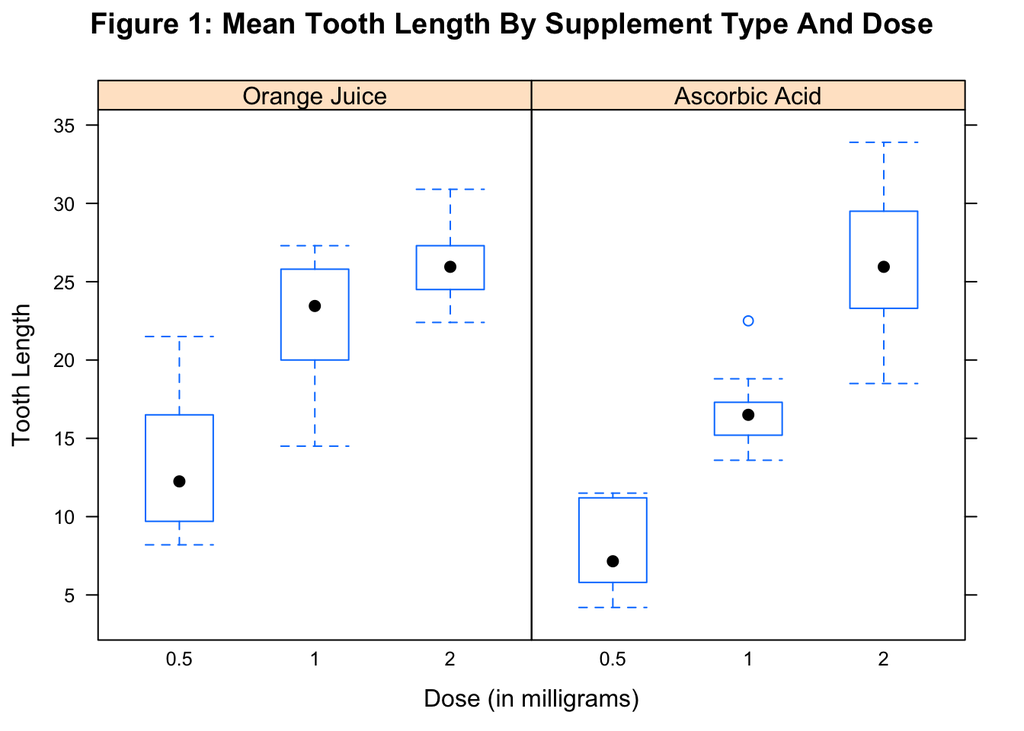

```r
library(lattice)
with(ToothGrowth, bwplot(len ~ dose | supp, layout = c(2, 1),
                         xlab = "Dose (in milligrams)",
                         ylab = "Tooth Length",
                         main = "Figure 1: Mean Tooth Length By Supplement Type And Dose"))
```

## Summary of the Data

Create an aggregate data file with the mean tooth length for each of the supplement type x dose treatments.

```r
library(reshape2)
df.aggr <- melt(ToothGrowth, id = c("supp", "dose"))
df.aggr <- dcast(df.aggr, supp + dose ~ variable, mean)
names(df.aggr) <- c("Supplement", "Dose", "Mean Tooth Length")
df.aggr
```

```
##      Supplement Dose Mean Tooth Length
## 1  Orange Juice  0.5             13.23
## 2  Orange Juice    1             22.70
## 3  Orange Juice    2             26.06
## 4 Ascorbic Acid  0.5              7.98
## 5 Ascorbic Acid    1             16.77
## 6 Ascorbic Acid    2             26.14
```

## Hypothesis Tests

*Note: For the purposes of this project, t-test confidence intervals will be used to compare the treatment groups. A factorial analysis of variance is much better suited to this type of experimental design, but will not be considered here.*

In order to test for the presence of a supplement type x dose interaction, first create six subsets of the data.

```r
sAA_d.5 <- ToothGrowth[1:10, ] # ascorbic acid, 0.5 mg dose
sAA_d1 <- ToothGrowth[11:20, ] # ascorbic acid, 1 mg dose
sAA_d2 <- ToothGrowth[21:30, ] # ascorbic acid, 2 mg dose
sOJ_d.5 <- ToothGrowth[31:40, ] # orange juice, 0.5 mg dose
sOJ_d1 <- ToothGrowth[41:50, ] # orange juice, 1 mg dose
sOJ_d2 <- ToothGrowth[51:60, ] # orange juice, 2 mg dose
```

Create three sets of confidence intervals to compare the three dose levels for orange juice and ascorbic acid.

```r
t.test(sOJ_d.5$len, sAA_d.5$len, paired = FALSE, var.equal = TRUE)$conf # 0.5 mg dose
```

```
## [1] 1.770262 8.729738
## attr(,"conf.level")
## [1] 0.95
```

```r
t.test(sOJ_d1$len, sAA_d1$len, paired = FALSE, var.equal = TRUE)$conf # 1 mg dose
```

```
## [1] 2.840692 9.019308
## attr(,"conf.level")
## [1] 0.95
```

```r
t.test(sOJ_d2$len, sAA_d2$len, paired = FALSE, var.equal = TRUE)$conf # 2 mg dose
```

```
## [1] -3.722999  3.562999
## attr(,"conf.level")
## [1] 0.95
```

The confidence intervals show that at dose levels of 0.5 and 1 mg, the mean tooth length is significantly longer when orange juice is the supplement type (the confidence intervals do not contain 0). However, at a dose level of 2 mg, there is no significant difference in tooth length between orange juice and ascorbic acid (the confidence interval contains 0).

## Conclusions

The confidence intervals support the hypothesis of a supplement type x dose interaction. Orange juice is associated with longer tooth length compared to ascorbic acid, but only at doses of less than 2 mg. These conclusions assume *normality* (tooth length in guinea pigs is normally distributed), *independence* (observations under one treatment are not linked in any way to observations under another treatment), and *homogeneity of variance* (the variances across the treatment groups are equal).